# clean_notebook

```python
# Install the libraries (if using binder)
# !pip install numpy
# !pip install pandas
# !pip install matplotlib
# !pip install seaborn
# !pip install pylab
```

```python
import numpy as np
import pandas as pd
import matplotlib.pyplot as plt
import seaborn as sns
import pylab as plot
```

### Reading the csv file and get it into a dataframe format

```python
df = pd.read_csv("pollution_us_2000_2016.csv")
```

```python
print(f'The dataframe has {len(df)} rows and {df.shape[1]} columns')
```

```
The dataframe has 1746661 rows and 29 columns
```

Based on the above numbers, one concludes that the dataframe corresponds to very large dataset *(Big Data)*. Therefore, it is not advisable to view the entire dataframe as that will be a super memory expensive task. One needs to perform the analytics in a smarter way so as to the get the desired results while making sure not to put too much load on the memory.

```python
states = df['State'].unique()
num_states = len(states)
```

```python
print(f'There are {num_states} states in the dataset.')
```

```
There are 47 states in the dataset.
```

```python
print(f'The columns in the dataframe are given by \n{df.columns}')
```

```
The columns in the dataframe are given by
Index(['Unnamed: 0', 'State Code', 'County Code', 'Site Num', 'Address',
       'State', 'County', 'City', 'Date Local', 'NO2 Units', 'NO2 Mean',
       'NO2 1st Max Value', 'NO2 1st Max Hour', 'NO2 AQI', 'O3 Units',
       'O3 Mean', 'O3 1st Max Value', 'O3 1st Max Hour', 'O3 AQI', 'SO2 Units',
       'SO2 Mean', 'SO2 1st Max Value', 'SO2 1st Max Hour', 'SO2 AQI',
       'CO Units', 'CO Mean', 'CO 1st Max Value', 'CO 1st Max Hour', 'CO AQI'],
      dtype='object')
```

One would now like to get rid of the columns that are not going to be useful for our analytics.

```python
# columns to be dropped
drop_cols = ['Unnamed: 0', 'State Code', 'County Code', 'Site Num', 'Address', 'City', 'NO2 1st Max Value', 'NO2 1st Max Hour', 'NO2 AQI', 'O3 1st Max Value', 'O3 1st Max Hour', 'O3 AQI', 'SO2 1st Max Value', 'SO2 1st Max Hour', 'SO2 AQI', 'CO 1st Max Value', 'CO 1st Max Hour', 'CO AQI']
```

```python
df.drop(drop_cols, axis=1, inplace=True)
```

```python
print(f'The dataframe now contains {len(df)} rows and {df.shape[1]} columns')
```

```
The dataframe now contains 1746661 rows and 11 columns
```

To get some idea about the entries in the dataframe, instad of looking at the entire dataframe, one peeks at only few rows.

```python
df.head()
```

|  | State | County | Date Local | NO2 Units | NO2 Mean | O3 Units | O3 Mean | SO2 Units | SO2 Mean | CO Units | CO Mean |
| --- | --- | --- | --- | --- | --- | --- | --- | --- | --- | --- | --- |
| 0 | Arizona | Maricopa | 2000-01-01 | Parts per billion | 19.041667 | Parts per million | 0.022500 | Parts per billion | 3.000000 | Parts per million | 1.145833 |
| 1 | Arizona | Maricopa | 2000-01-01 | Parts per billion | 19.041667 | Parts per million | 0.022500 | Parts per billion | 3.000000 | Parts per million | 0.878947 |
| 2 | Arizona | Maricopa | 2000-01-01 | Parts per billion | 19.041667 | Parts per million | 0.022500 | Parts per billion | 2.975000 | Parts per million | 1.145833 |
| 3 | Arizona | Maricopa | 2000-01-01 | Parts per billion | 19.041667 | Parts per million | 0.022500 | Parts per billion | 2.975000 | Parts per million | 0.878947 |
| 4 | Arizona | Maricopa | 2000-01-02 | Parts per billion | 22.958333 | Parts per million | 0.013375 | Parts per billion | 1.958333 | Parts per million | 0.850000 |

### Conversion of Units to achieve uniformity

By peeking at the above tiny dataframe, one sees that the units are not uniform for all the gases. Before converting all the units, one must make sure if all the entries in particular units column are the same, i.e., for a gas *x*, one would like to make sure if it is always measured in the same units.}

```python
def same_units(df, col):
    if len(df[col].unique()) == 1:
        return True
    return False

def get_units(df, col):
    return df[col].unique()
```

```python
same_units(df, 'NO2 Units')
```

```
True
```

```python
get_units(df, 'NO2 Units')
```

```
array(['Parts per billion'], dtype=object)
```

```python
same_units(df, 'SO2 Units')
```

```
True
```

```python
get_units(df, 'SO2 Units')
```

```
array(['Parts per billion'], dtype=object)
```

```python
same_units(df, 'O3 Units')
```

```
True
```

```python
get_units(df, 'O3 Units')
```

```
array(['Parts per million'], dtype=object)
```

```python
same_units(df, 'CO Units')
```

```
True
```

```python
get_units(df, 'CO Units')
```

```
array(['Parts per million'], dtype=object)
```

Note that, $NO_2$ and $SO_2$ are **always** measured in parts per billion (ppb), while $O_3$ and $CO$ are **always** measured in parts per million (ppm).

A standard unit in the field of science is parts per million (ppm), hence one would like to convert $NO_2$ and $SO_2$ into parts per million (ppm).

```python
df['NO2 Mean'] = df['NO2 Mean']/1000
df['SO2 Mean'] = df['SO2 Mean']/1000
```

The columns describing the units are now irrelevant, hence, one would like to discard all of these columns to get even more finer dataframe.

```python
unit_cols = ['NO2 Units', 'SO2 Units', 'O3 Units', 'CO Units']
df.drop(unit_cols, axis=1, inplace=True)
```

Before, moving ahead, a good practice is to check if there are any NaN, i.e., missing values in the dataframe.

```python
df.isna().any()
```

```
State         False
County        False
Date Local    False
NO2 Mean      False
O3 Mean       False
SO2 Mean      False
CO Mean       False
dtype: bool
```

Therefore, none of the above columns contain any missing value. Great!!

### Rename the 'Date Local' column and make it the index of the dataframe.

To see the trends with time, it is a good practice to have the date column as the index of the dataframe.

```python
df.rename(columns={'Date Local':'Date'}, inplace=True)
```

```python
# first check the type of the Date column
df['Date'].dtypes
```

```
dtype('O')
```

One would like to convert this into a 'DateTime Object' since that makes it easier to parse dates and do analysis on it.

```python
df['Date'] = pd.to_datetime(df['Date'])
```

```python
# make 'Date' as the index of the dataframe
df.set_index('Date', inplace=True)
```

```python
# let us take a peek at the dataframe
df.tail()
```

| Date | State | County | NO2 Mean | O3 Mean | SO2 Mean | CO Mean |
| --- | --- | --- | --- | --- | --- | --- |
| 2016-03-30 | Wyoming | Laramie | 0.001083 | 0.043917 | 0.000000 | 0.091667 |
| 2016-03-31 | Wyoming | Laramie | 0.000939 | 0.045263 | -0.000023 | 0.067714 |
| 2016-03-31 | Wyoming | Laramie | 0.000939 | 0.045263 | -0.000023 | 0.100000 |
| 2016-03-31 | Wyoming | Laramie | 0.000939 | 0.045263 | 0.000000 | 0.067714 |
| 2016-03-31 | Wyoming | Laramie | 0.000939 | 0.045263 | 0.000000 | 0.100000 |

### Insert Total Mean Column

In order to quantify $NO_2$, $O_3$, $SO_2$ and $CO$ as one single entity for each state, one would like to get a **Total Mean** column, that allows us to do exactly that. The entries of this columns will act as a a measure for each state and will help us see how each of these states have performed through time.

```python
df['Total Mean'] = df['NO2 Mean'] + df['SO2 Mean'] + df['CO Mean'] + df['O3 Mean']
df.head()
```

| Date | State | County | NO2 Mean | O3 Mean | SO2 Mean | CO Mean | Total Mean |
| --- | --- | --- | --- | --- | --- | --- | --- |
| 2000-01-01 | Arizona | Maricopa | 0.019042 | 0.022500 | 0.003000 | 1.145833 | 1.190375 |
| 2000-01-01 | Arizona | Maricopa | 0.019042 | 0.022500 | 0.003000 | 0.878947 | 0.923489 |
| 2000-01-01 | Arizona | Maricopa | 0.019042 | 0.022500 | 0.002975 | 1.145833 | 1.190350 |
| 2000-01-01 | Arizona | Maricopa | 0.019042 | 0.022500 | 0.002975 | 0.878947 | 0.923464 |
| 2000-01-02 | Arizona | Maricopa | 0.022958 | 0.013375 | 0.001958 | 0.850000 | 0.888292 |

### Get individual Dataframe for each of the Gases

The goal now is to create individual dataframes for each of the gases, with columns representing each of the states. One would also like to discard the states that have missing value for any of the years.

Note that, we the original dataset has 47 states (as computed before). It might be the case, that not all of them have values recorded for all the yeras from 2000 to 2016. We would like to get rid of them.

```python
def get_df(gas_name):
    """

    """

    global df

    df_year_list = [df.loc[str(i)] for i in range(2000, 2017)]

    # populates dictionary with states as the keys and list of values
    dict_of_lists = {state:[] for state in states}

    for df_year in df_year_list:
        for state in states:
            state_vals = df_year[df_year['State'] == state]
            dict_of_lists[state].append(state_vals[gas_name].mean())

    # convert the dictionary to a dataframe
    result = pd.DataFrame(dict_of_lists)

    # change the indices so that they reflect years
    index_list = [item for item in range(2000, 2017)]
    result.index = index_list

    # get only the columns for which one has non-NaN values.
    result.dropna(axis = 1, inplace=True)
    return result
```

```python
# dataframe for no2
no2_df = get_df('NO2 Mean')
```

```python
# dataframe for so2
so2_df = get_df('SO2 Mean')
```

```python
# dataframe for co
co_df = get_df('CO Mean')
```

```python
# dataframe for o3
o3_df = get_df('O3 Mean')
```

```python
# dataframe for 'Total Mean'
total_df = get_df('Total Mean')
```

Let us check one of the dataframes to see how it looks:

```python
total_df
```

|  | Arizona | California | Colorado | District Of Columbia | Florida | Illinois | Indiana | Kansas | Louisiana | New York | North Carolina | Oklahoma | Pennsylvania | Texas |
| --- | --- | --- | --- | --- | --- | --- | --- | --- | --- | --- | --- | --- | --- | --- |
| 2000 | 0.798202 | 0.687464 | 0.645494 | 1.224127 | 0.765760 | 0.752500 | 0.925394 | 0.794784 | 0.801407 | 0.514070 | 0.671734 | 0.090925 | 0.348376 | 0.480331 |
| 2001 | 0.695511 | 0.666567 | 0.672161 | 1.127486 | 0.676223 | 0.640492 | 0.433128 | 0.374191 | 0.869818 | 0.547200 | 0.590789 | 0.076960 | 0.369254 | 0.428627 |
| 2002 | 0.754270 | 0.646514 | 0.541882 | 1.214099 | 0.506577 | 0.636477 | 0.499557 | 0.430260 | 0.757456 | 0.494625 | 0.484683 | 0.098953 | 0.308522 | 0.385840 |
| 2003 | 0.679421 | 0.618316 | 0.592142 | 0.946706 | 0.476274 | 0.559350 | 0.490029 | 0.355004 | 0.701848 | 0.581065 | 0.531398 | 0.085071 | 0.310436 | 0.504747 |
| 2004 | 0.554335 | 0.560905 | 0.657593 | 0.664519 | 0.556943 | 0.621316 | 0.613716 | 0.417344 | 0.603334 | 0.485550 | 0.473690 | 0.054292 | 0.368931 | 0.384332 |
| 2005 | 0.665032 | 0.500273 | 0.662426 | 0.895856 | 0.600239 | 0.503868 | 0.472980 | 0.423212 | 0.514256 | 0.451008 | 0.564364 | 0.059417 | 0.260185 | 0.357994 |
| 2006 | 0.603409 | 0.486094 | 0.618916 | 1.163044 | 0.427287 | 0.412583 | 0.704377 | 0.418019 | 0.413075 | 0.367027 | 0.450918 | 0.152595 | 0.276181 | 0.303200 |
| 2007 | 0.553691 | 0.456998 | 0.596887 | 1.245813 | 0.319266 | 0.366152 | 0.494955 | 0.463035 | 0.421861 | 0.412721 | 0.421601 | 0.241615 | 0.284100 | 0.267850 |
| 2008 | 0.470645 | 0.431742 | 0.452051 | 1.271644 | 0.257114 | 0.312789 | 0.460137 | 0.445292 | 0.320464 | 0.361006 | 0.364179 | 0.185803 | 0.227020 | 0.260187 |
| 2009 | 0.466621 | 0.434052 | 0.397771 | 0.912213 | 0.372236 | 0.301144 | 0.271358 | 0.336629 | 0.258601 | 0.281663 | 0.330452 | 0.254057 | 0.274872 | 0.233453 |
| 2010 | 0.408035 | 0.383384 | 0.405850 | 0.933106 | 0.428707 | 0.388603 | 0.206066 | 0.456881 | 0.286605 | 0.349065 | 0.369665 | 0.254343 | 0.310210 | 0.265000 |
| 2011 | 0.387629 | 0.399653 | 0.379762 | 0.712977 | 0.467284 | 0.379686 | 0.101368 | 0.490146 | 0.259645 | 0.319113 | 0.378816 | 0.271505 | 0.270176 | 0.237008 |
| 2012 | 0.387856 | 0.375469 | 0.418572 | 0.638381 | 0.414831 | 0.335710 | 0.447247 | 0.554373 | 0.255887 | 0.388655 | 0.317326 | 0.208309 | 0.260380 | 0.220559 |
| 2013 | 0.365061 | 0.393439 | 0.351149 | 0.378432 | 0.327972 | 0.327712 | 0.309183 | 0.474897 | 0.237950 | 0.350030 | 0.322816 | 0.209758 | 0.202843 | 0.211949 |
| 2014 | 0.448863 | 0.382796 | 0.363579 | 0.396666 | 0.488679 | 0.335580 | 0.272094 | 0.302824 | 0.301779 | 0.317352 | 0.304323 | 0.193185 | 0.227569 | 0.213488 |
| 2015 | 0.397079 | 0.371410 | 0.435283 | 0.314154 | 0.543955 | 0.337879 | 0.289820 | 0.324035 | 0.254877 | 0.303811 | 0.292976 | 0.274168 | 0.209323 | 0.242044 |
| 2016 | 0.506634 | 0.394440 | 0.497141 | 0.301591 | 0.608771 | 0.345647 | 0.285532 | 0.288168 | 0.273809 | 0.336514 | 0.284278 | 0.312851 | 0.131374 | 0.264461 |

```python
print(f'There are {len(total_df.columns)} states in the datframe corresponding to the total mean.')
```

```
There are 14 states in the datframe corresponding to the total mean.
```

Naturally, one would like to know if all the dataframes have same states.

```python
print(total_df.columns == no2_df.columns)
print(no2_df.columns == o3_df.columns)
print(o3_df.columns == so2_df.columns)
print(so2_df.columns == co_df.columns)
```

```
[ True  True  True  True  True  True  True  True  True  True  True  True
  True  True]
[ True  True  True  True  True  True  True  True  True  True  True  True
  True  True]
[ True  True  True  True  True  True  True  True  True  True  True  True
  True  True]
[ True  True  True  True  True  True  True  True  True  True  True  True
  True  True]
```

Therefore, only these 14 states have their data recorded from 2000 to 2016. Rest other states have missing data, hence are discareded in our analysis.

# Line Plots

Let us plot individual line plots for each of the gases to infer a visualization trend of how each of the 14 states are performed from 2000 to 2016 for each of the gases.

```python
params = {'legend.fontsize': 23,
          'legend.handlelength': 2,
         'font.size': 27}
plot.rcParams.update(params)
```

```python
# Setting the style of the Seaborn line Plots
sns.set_style("whitegrid")
plot_colors = ['#ff0000', '#940606', '#5c1414', '#ff8c00', '#965709', '#b59509', '#91790c', '#84910c', '#c1db00', '#37db00', '#216e08', '#00ffd9', '#033b6b', '#0089ff']
plot_line_styles = ['-', '--','-.', '-.', '--', '-', '--','-.', '-.', '--', '--','-.', '-.', '-']
```

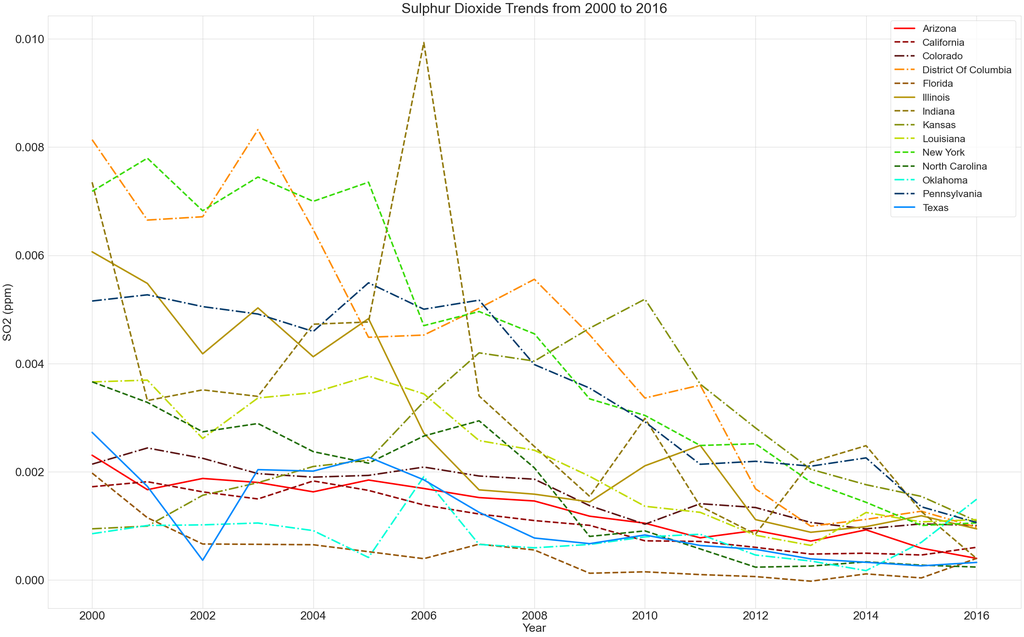

```python
# SO2
so2_df.plot(figsize=(40,25), color = plot_colors, linewidth=3.5, style = plot_line_styles)
plt.title("Sulphur Dioxide Trends from 2000 to 2016")
plt.xlabel("Year")
plt.ylabel("SO2 (ppm)")
```

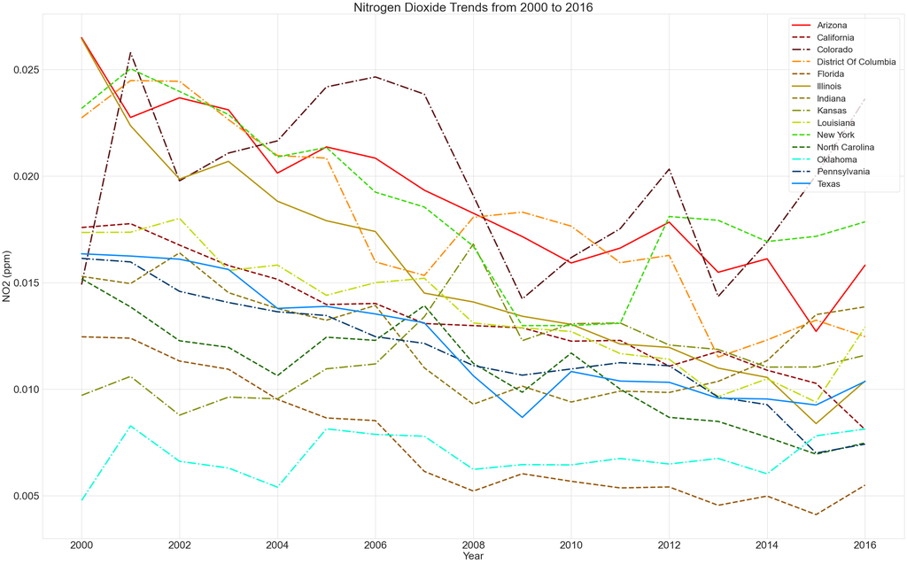

```python
# NO2
no2_df.plot(figsize=(40,25), color = plot_colors, linewidth=3.5, style = plot_line_styles)
plt.title("Nitrogen Dioxide Trends from 2000 to 2016")
plt.xlabel("Year")
plt.ylabel("NO2 (ppm)")
```

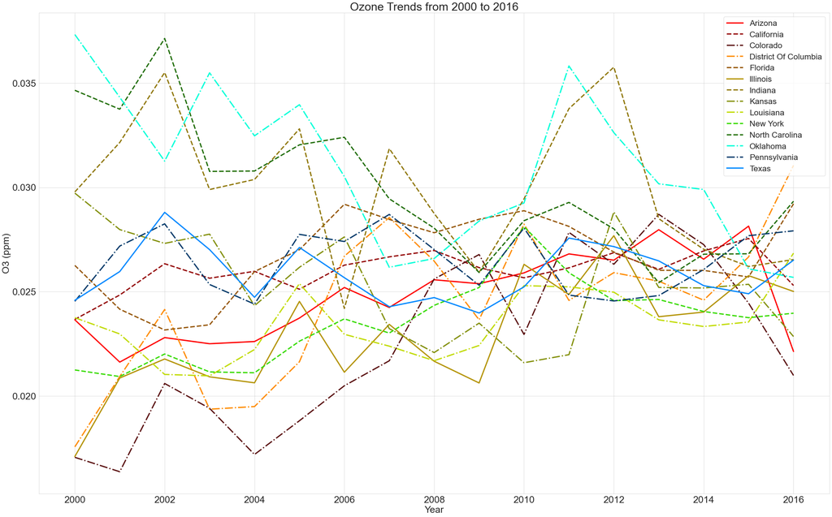

```python
# O3
o3_df.plot(figsize=(40,25), color = plot_colors, linewidth=3.5, style = plot_line_styles)
plt.title("Ozone Trends from 2000 to 2016")
plt.xlabel("Year")
plt.ylabel("O3 (ppm)")
```

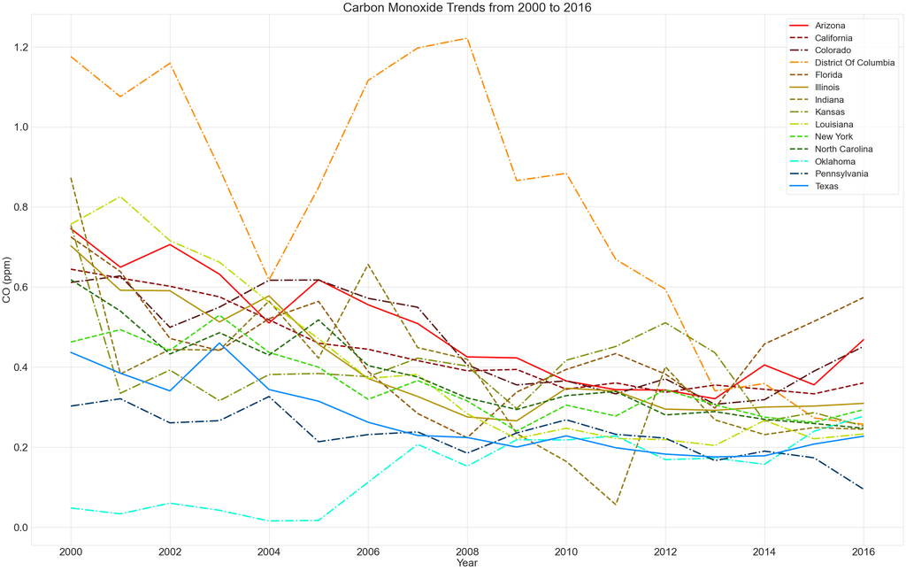

```python
# CO
co_df.plot(figsize=(40,25), color = plot_colors, linewidth=3.5, style = plot_line_styles)
plt.title("Carbon Monoxide Trends from 2000 to 2016")
plt.xlabel("Year")
plt.ylabel("CO (ppm)")
```

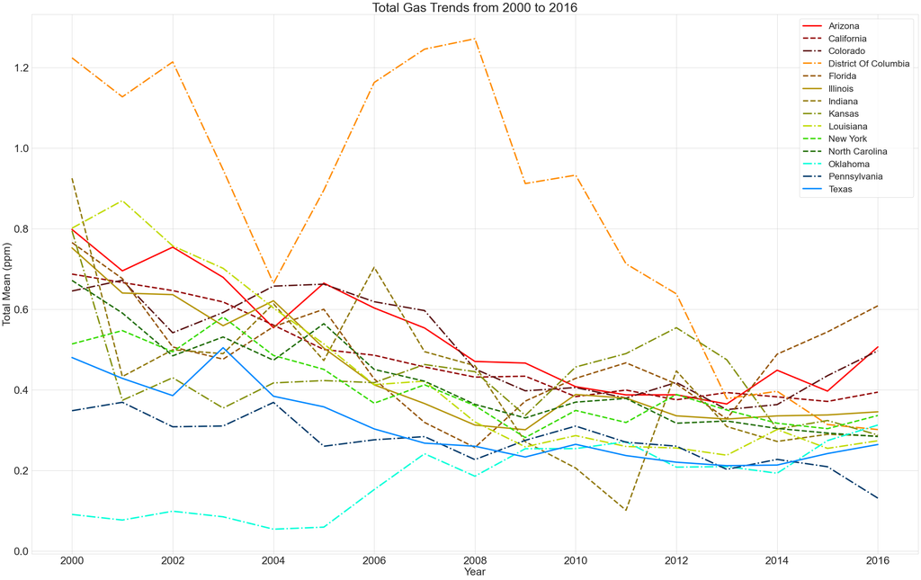

```python
# Total Mean
total_df.plot(figsize=(40,25), color = plot_colors, linewidth=3.5, style = plot_line_styles)
plt.title("Total Gas Trends from 2000 to 2016")
plt.xlabel("Year")
plt.ylabel("Total Mean (ppm)")
```